# Reproducible Research: Project 1

YLL

## Dataset: Daily Steps

The dataset for this project is downloaded from [here](https://d396qusza40orc.cloudfront.net/repdata%2Fdata%2Factivity.zip), and unzips to a CSV file.

The file is read into R using read.csv and the NAs are removed for the initial analyses.

```r
data_raw <- read.csv("activity.csv")
data <- data_raw[!is.na(data_raw$steps),]
```

## Average Daily Steps

Using the data with NAs removed, the daily total steps are calculated and displayed in a histogram.  
The mean and median of the daily steps are computed using R functions mean and median.

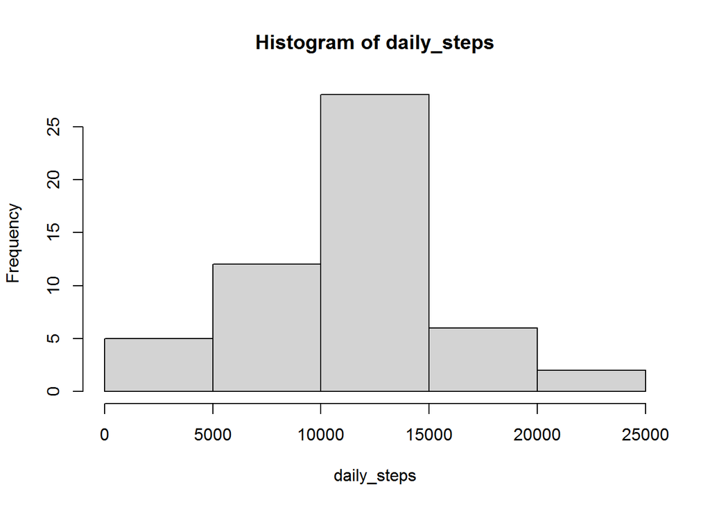

```r
daily_steps <- tapply (data$steps, as.factor(data$date), sum)
daily_steps <- daily_steps[!is.na(daily_steps)]
hist(daily_steps)
```

```r
print(paste("Mean daily steps: ", mean(daily_steps)))
```

```
## [1] "Mean daily steps:  10766.1886792453"
```

```r
print(paste("Median of daily steps: ", median(daily_steps)))
```

```
## [1] "Median of daily steps:  10765"
```

## Average Daily Activity Pattern

To look at the mean of the number of steps every day for each time interval, the data with NAs removed is used to create a plot.  
The interval with the highest number of steps is calculated by identifying the largest average number of steps across all intervals.

```r
intervals <- unique(data$interval)
interval_steps <- tapply (data$steps, as.factor(data$interval), mean)
interval_steps <- bind_cols(interval_steps,intervals)
```

```
## * NA -> ...1
## * NA -> ...2
```

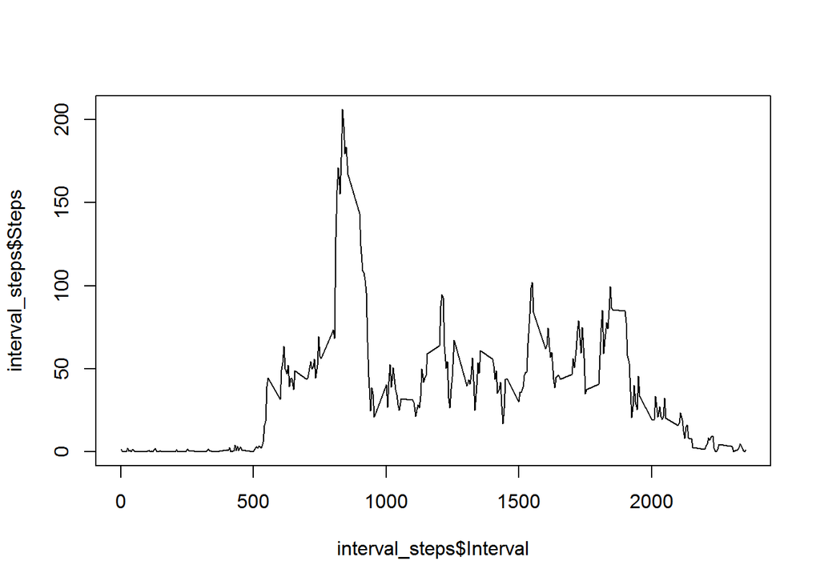

```r
names(interval_steps) <- c("Steps", "Interval")
plot(interval_steps$Interval,interval_steps$Steps,type="l")
```

```r
max_point <- interval_steps[interval_steps$Steps==max(interval_steps$Steps),]
print (paste("Interval with maximum steps: ", max_point[2]))
```

```
## [1] "Interval with maximum steps:  835"
```

## Imputing Missing Values

All the NAs from the original data is replaced with the average value of the time interval to which the missing value belongs.

```r
data_complete <- data_raw
nas <- is.na(data_complete$steps)
num_nas <- sum(nas)
for (i in 1:length(data_complete$steps)) {
  if (is.na(data_complete[i,1])) {
    data_complete[i,1] <- interval_steps[interval_steps$Interval==data_complete[i,3],1]
  }
}
```

## Recalculate Average Daily Steps

Using the new completed data, the average daily steps is shown in a histogram and the mean and median are re-calculated.

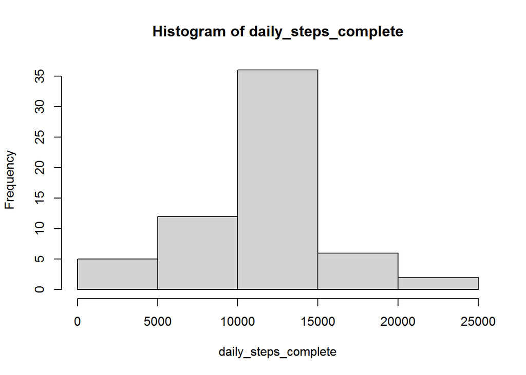

```r
daily_steps_complete <- tapply (data_complete$steps, as.factor(data_complete$date), sum)
daily_steps_complete <- daily_steps_complete[!is.na(daily_steps_complete)]
hist(daily_steps_complete)
```

```r
print(paste("Mean daily steps: ", mean(daily_steps_complete)))
```

```
## [1] "Mean daily steps:  10766.1886792453"
```

```r
print(paste("Median of daily steps: ", median(daily_steps_complete)))
```

```
## [1] "Median of daily steps:  10766.1886792453"
```

## Activity Pattern Difference

To explore the difference in activity patterns between weekdays and weekends, the completed data is analyzed to produce a plot with separate points for weekdays and weekends.

First, the “date” column is converted to class Date so that each date can be classified as either weekday or weekend. A new column indicating whether an observation is a weekday or not is added to the data.

```r
data_complete$date <- as.Date(data_complete$date, format="%Y-%m-%d")
weekdays <- c("Monday", "Tuesday", "Wednesday", "Thursday", "Friday")
data_complete <- mutate (data_complete,
                         isWeekday=(weekdays(data_complete$date) %in% weekdays))
```

Next, two subsets of the data are created - one for the weekdays and another for the weekends. The average steps per each time interval is calculated for each data subset independently. Lastly, both data subset are shown in the same plot.

```r
weekday_steps <- filter(data_complete, data_complete$isWeekday==TRUE)
weekend_steps <- filter(data_complete, data_complete$isWeekday==FALSE)

weekday_ave <- tapply (weekday_steps$steps, as.factor(weekday_steps$interval), mean)
weekday_ave <- bind_cols(weekday_ave,intervals)
```

```
## * NA -> ...1
## * NA -> ...2
```

```r
names(weekday_ave) <- c("Steps", "Interval")

weekend_ave <- tapply (weekend_steps$steps, as.factor(weekend_steps$interval), mean)
weekend_ave <- bind_cols(weekend_ave,intervals)
```

```
## * NA -> ...1
## * NA -> ...2
```

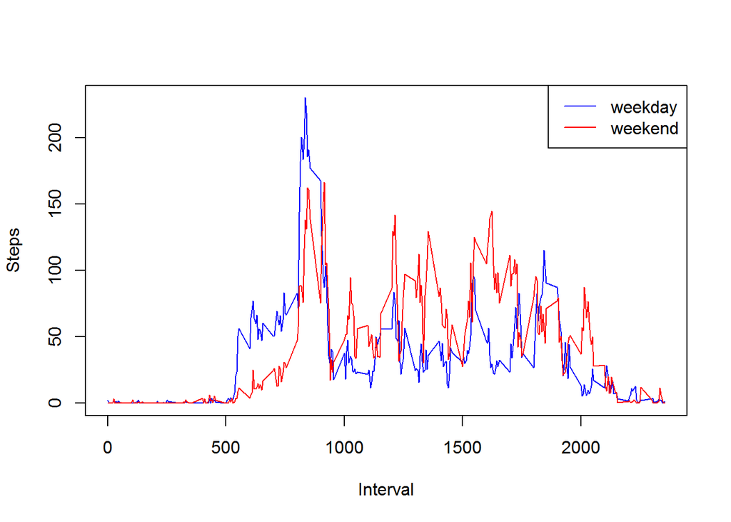

```r
names(weekend_ave) <- c("Steps", "Interval")

plot(weekday_ave$Interval, weekday_ave$Steps,
     type="l",
     col="blue",
     xlab="Interval", ylab="Steps")
points(weekend_ave$Interval, weekend_ave$Steps,
       type="l",
       col="red")
legend ("topright",
        lty=1,
        col=c("blue","red"),
        legend=c("weekday","weekend"))
```

End of report.